# HW7_20203374_이호용

## 1 - (1)

### 1. Load data and fit the model

```r
rm(list=ls())
load('C:/Users/Hoyong/Downloads/RABE5.RData')
df <- P219
head(df)
```

```
##         H     P       D
## 1 0.09090 2.200 0.03635
## 2 0.08942 2.222 0.03345
## 3 0.09755 2.244 0.03870
## 4 0.09550 2.267 0.03745
## 5 0.09678 2.280 0.04063
## 6 0.10327 2.289 0.04237
```

```r
lm <- lm(H ~ P, data=df)
summary(lm)
```

```
##
## Call:
## lm(formula = H ~ P, data = df)
##
## Residuals:
##        Min         1Q     Median         3Q        Max
## -0.0083683 -0.0021329  0.0005252  0.0025572  0.0080754
##
## Coefficients:
##              Estimate Std. Error t value Pr(>|t|)
## (Intercept) -0.060884   0.010416  -5.845 5.89e-06 ***
## P            0.071410   0.004234  16.867 1.91e-14 ***
## ---
## Signif. codes:  0 '***' 0.001 '**' 0.01 '*' 0.05 '.' 0.1 ' ' 1
##
## Residual standard error: 0.00408 on 23 degrees of freedom
## Multiple R-squared:  0.9252, Adjusted R-squared:  0.922
## F-statistic: 284.5 on 1 and 23 DF,  p-value: 1.911e-14
```

### 2. Residual plot

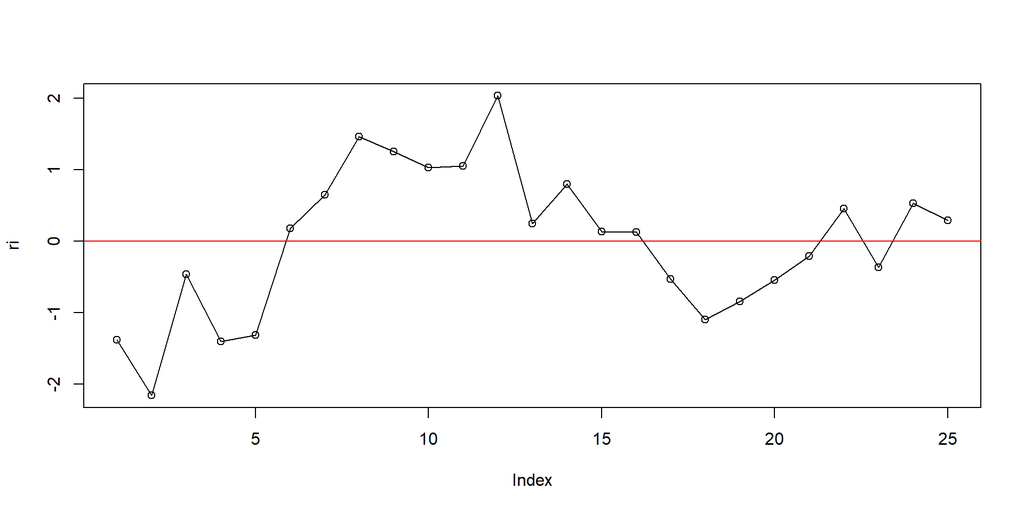

```r
ri <- rstandard(lm)
plot(ri, type='o')
abline(h=0, lty=1, col='red')
```

It shows pattern. It does not seem to be randomly scattered, *not independent.*  
When comparing the points with (line ri = 0), it is shown that the points are grouped.  
It seems to have a *positive autocorrelation.*

## 1 - (2)

The plot above have shown some kind of **positive autocorrelation**. So we can define a hypothesis test based on the **Runs test.**

Let $P_{++}$ = Prob($e_i>0$|$e_{i-1}>0$),  
$P_{-+}$ = Prob($e_i>0$|$e_{i-1}<0$).

### 1. One-sided hypothesis test

$H_0 : P_{++} = P_{-+}$ (Independent)

$H_1 : P_{++} > P_{-+}$ (Positive correlation)

### 2. Two-sided hypothesis test

$H_0 : P_{++} = P_{-+}$ (Independent)

$H_1 : P_{++} \neq P_{-+}$ (Correlation exist)

## 1 - (3)

**Runs test**

```r
library(randtests) # load library
```

### 1. One-sided hypothesis test

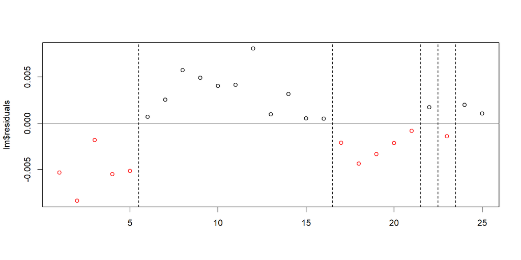

```
##
##  Runs Test
##
## data:  lm$residuals
## statistic = -3.0366, runs = 6, n1 = 14, n2 = 11, n = 25, p-value =
## 0.001196
## alternative hypothesis: trend
```

```r
runs.test(lm$residuals, alternative = 'left.sided', threshold=0, plot=TRUE)
```

As the result of the Runs test, runs=6, and the plot showed positive correlation.

*p-value = 0.001196 < 0.01(*$\alpha$*), thus reject* $H_0$.  
Accept $H_1$ *:* $P_{++} > P_{-+}$*.(Positive correlation).*

### 2. Two-sided hypothesis test

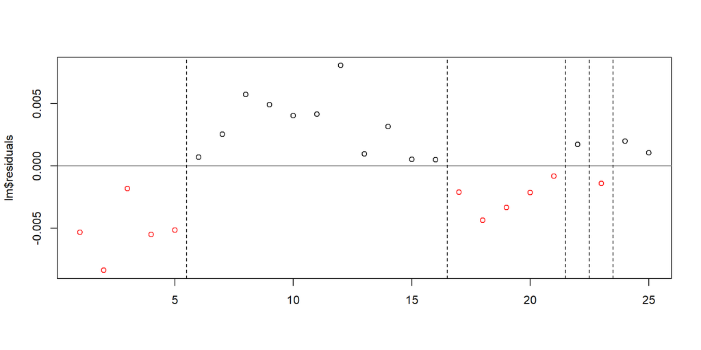

```
##
##  Runs Test
##
## data:  lm$residuals
## statistic = -3.0366, runs = 6, n1 = 14, n2 = 11, n = 25, p-value =
## 0.002393
## alternative hypothesis: nonrandomness
```

```r
runs.test(lm$residuals, alternative = 'two.sided',threshold=0, plot=TRUE)
```

As the result of the Runs test, runs=6, and the plot showed positive correlation.

Actually, the difference between one-sided, two-sided result is just p-value.

Thus we might notice p-value was so small, and it will reject $H_0$.

*p-value = 0.002393 < 0.01 (*$\alpha$*), Reject* $H_0$*.*

*Accept* $H_1 : P_{++} \neq P_{-+}$.*(Correlation exists).*

## 1 - (4)

### 1. Calculate $\hat{\rho}$

```r
rho_hat <- acf(lm$residuals,plot=FALSE)[1]
rho_hat # we can use acf function to calculate rho hat
```

```
##
## Autocorrelations of series 'lm$residuals', by lag
##
##     1
## 0.651
```

### 2. Calculate d

d $\approx$ 2(1-$\hat{\rho}$), where $\hat{\rho}$ = 0.651

```r
rho_hat <- 0.651
d <- 2*(1-rho_hat) ; d
```

```
## [1] 0.698
```

We can use above approximate (d = 0.698) value or  
We can use below table’s (d = 0.62084).

```r
library(lmtest)
dwtest(lm, alternative = 'greater')
```

```
##
##  Durbin-Watson test
##
## data:  lm
## DW = 0.62084, p-value = 6.645e-06
## alternative hypothesis: true autocorrelation is greater than 0
```

But since positive correlation was suspicious. I’ll use (d = 0.698) for more conservative test.

### 3. One-sided hypothesis test

$H_0 : \rho = 0$ ($d$ > $d_U$)

$H_1 : \rho > 0$ ($d$ < $d_L$), $\alpha=0.05$

Reject $H_0$, if ($d$ < $d_L$)

```r
n <-  n <- dim(df)[1]
p <- length(lm$coefficients)-1
alpha <- 0.05
print(c(n,p,alpha))
```

```
## [1] 25.00  1.00  0.05
```

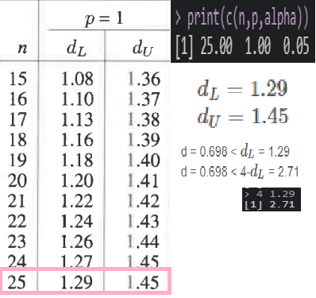

$d$ *<* $d_L$*,* Reject $H_0$.  
*Accept* $H_1 : \rho > 0$*.*

### 4. Two-sided hypothesis test

$H_0 : \rho = 0$ ($d_U$ < $d$ < 4-$d_U$)

$H_1 : \rho \neq 0$ ($d$ < $d_L$ or $d$ > 4-$d_L$), $\alpha=0.1$

Reject $H_0$ if, ($d$ < $d_L$ or $d$ > 4-$d_L$)

$d$ *<* $d_L$*, Reject* $H_0$*.*

*Accept* $H_1 : \rho \neq 0$.

## 1 - (5)

### 1. Cochrance and Orcutt

Estimate $\hat{\beta_0}$, $\hat{\beta_1}$

```r
y_star <- df$H[2:n] - rho_hat*df$H[1:n-1]
x_star <- df$P[2:n] - rho_hat*df$P[1:n-1]
lm_new <- lm(y_star ~ x_star)
summary(lm_new)
```

```
##
## Call:
## lm(formula = y_star ~ x_star)
##
## Residuals:
##        Min         1Q     Median         3Q        Max
## -0.0056017 -0.0022087  0.0001742  0.0023565  0.0049509
##
## Coefficients:
##              Estimate Std. Error t value Pr(>|t|)
## (Intercept) -0.016473   0.007359  -2.238   0.0356 *
## x_star       0.066243   0.008375   7.909 7.13e-08 ***
## ---
## Signif. codes:  0 '***' 0.001 '**' 0.01 '*' 0.05 '.' 0.1 ' ' 1
##
## Residual standard error: 0.002916 on 22 degrees of freedom
## Multiple R-squared:  0.7398, Adjusted R-squared:  0.728
## F-statistic: 62.56 on 1 and 22 DF,  p-value: 7.131e-08
```

$\hat{\beta_0*}$ = -0.016473, $\hat{\beta_1*}$ = 0.066243  
$\hat{\beta_0}$ = $\hat{\beta_0*}/(1-\hat{\rho}$)

```r
beta0_hat <- -0.016473/(1-rho_hat)
beta0_hat
```

```
## [1] -0.04720057
```

$\hat{\beta_0}$ = -0.04720057

$\hat{\beta_1*}$ = $\hat{\beta_1}$ = 0.066243

### 2. Check Independency

Compare our **First model** with **Cochrance and Orcutt model.**

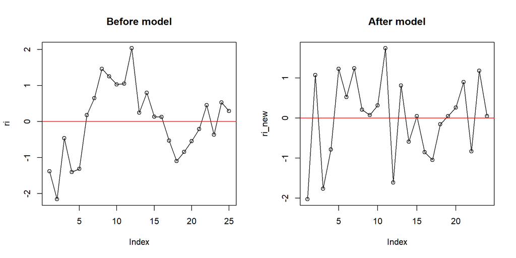

```r
ri_new <- rstandard(lm_new)
par(mfrow=c(1,2))
plot(ri, type='o', main='Before model')
abline(h=0, col='red', lty=1)
plot(ri_new, type='o', main='After model')
abline(h=0, col='red', lty=1)
```

After model(Cochrance and Orcutt), independency seems to be satisfied.

### 3. Durbin-Watson test

```r
acf(lm_new$residuals, plot=F)[1]
```

```
##
## Autocorrelations of series 'lm_new$residuals', by lag
##
##      1
## -0.275
```

$\hat{\rho}$ = -0.275 we have to check if this model have negative correlation.

$H_0 : \rho = 0$

$H_1 : \rho < 0$, $\alpha=0.05$

```r
dwtest(lm_new, alternative='less')
```

```
##
##  Durbin-Watson test
##
## data:  lm_new
## DW = 2.3825, p-value = 0.2315
## alternative hypothesis: true autocorrelation is less than 0
```

*p-value = 0.2315 > 0.05(*$\alpha$*). Accept* $H_0 : \rho = 0$*.*

### 4. Runs test

$\hat{\rho}$ = -0.275, check if this have negative autocorrelation.

$H_0 : P_{++} = P_{-+}$ (Independent)

$H_1 : P_{++} < P_{-+}$ (Negative autocorrelation), $\alpha=0.05$.

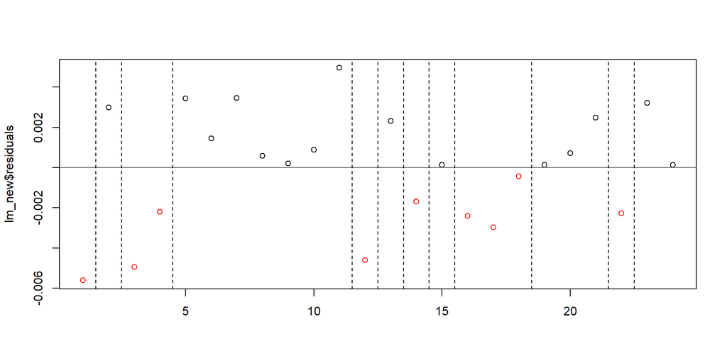

```
##
##  Runs Test
##
## data:  lm_new$residuals
## statistic = -0.11165, runs = 12, n1 = 15, n2 = 9, n = 24, p-value =
## 0.5445
## alternative hypothesis: first-order negative autocorrelation
```

```r
runs.test(lm_new$residuals, alternative = 'right.sided',threshold=0, plot=TRUE)
```

p-value = 0.5445 > $\alpha=0.05$. *Accept* $H_0 : P_{++} = P_{-+}$*(Independent).*  
*Due to above Runs-test, Durbin-Watson test, we can claim that residual’s independency is satisfied.*